# Sprawozdanie - uczenie maszynowe - studia niestacjonarne - zadania 1

## EDA

```python
import pandas as pd
import numpy as np
import os
import matplotlib.pyplot as plt
import seaborn as sns
from scipy.stats import pointbiserialr
from sklearn.model_selection import train_test_split, cross_val_score, KFold, StratifiedKFold
from sklearn.neighbors import KNeighborsClassifier
from sklearn.metrics import accuracy_score, classification_report, confusion_matrix, roc_auc_score, roc_curve
from sklearn.preprocessing import StandardScaler
from sklearn.linear_model import LogisticRegression

os.getcwd()
os.chdir("C:/Users/rados/OneDrive/Pulpit/AGH_zaoczne/semestr_1/machine_learning/cwiczenia/zajecia_1")

df = pd.read_csv('stroke_zaj1.csv', sep=';', decimal = ',', header = 0)
df.head()
```

|  | gender | age | hypertension | heart_disease | ever_married | work_type | Residence_type | avg_glucose_level | bmi | smoking_status | stroke |
| --- | --- | --- | --- | --- | --- | --- | --- | --- | --- | --- | --- |
| 0 | Male | 67 | 0 | 1 | Yes | Private | Urban | 228.69 | 36.6 | formerly smoked | 1 |
| 1 | Male | 80 | 0 | 1 | Yes | Private | Rural | 105.92 | 32.5 | never smoked | 1 |
| 2 | Female | 49 | 0 | 0 | Yes | Private | NaN | 171.23 | 34.4 | smokes | 1 |
| 3 | Female | 79 | 1 | 0 | Yes | Self-employed | Rural | 174.12 | 24.0 | never smoked | 1 |
| 4 | Male | 81 | 0 | 0 | Yes | Private | Urban | 186.21 | 29.0 | formerly smoked | 1 |

```python
cols = ['hypertension', 'heart_disease', 'ever_married',
        'work_type', 'Residence_type', 'smoking_status', 'stroke']

for col in cols:
    print(f"{col}: {df[col].unique()}")
```

```
hypertension: [0 1]
heart_disease: [1 0]
ever_married: ['Yes' 'No']
work_type: ['Private' 'Self-employed' 'Govt_job' nan 'children']
Residence_type: ['Urban' 'Rural' nan]
smoking_status: ['formerly smoked' 'never smoked' 'smokes' 'Unknown']
stroke: [1 0]
```

Można zauwazyć, że zmiennymi binarnymi są hypertension, heart_disease, ever_married, Residence_type (po zastosowaniu przekształceń braków danych) oraz zmienna objaśniana stroke. Z kolei zmienne work_type oraz smoking_status są zmiennymi typu kategorycznego.

```python
df.info()
```

```
<class 'pandas.core.frame.DataFrame'>
RangeIndex: 612 entries, 0 to 611
Data columns (total 11 columns):
 #   Column             Non-Null Count  Dtype
---  ------             --------------  -----
 0   gender             612 non-null    object
 1   age                612 non-null    int64
 2   hypertension       612 non-null    int64
 3   heart_disease      612 non-null    int64
 4   ever_married       612 non-null    object
 5   work_type          557 non-null    object
 6   Residence_type     552 non-null    object
 7   avg_glucose_level  568 non-null    float64
 8   bmi                549 non-null    float64
 9   smoking_status     612 non-null    object
 10  stroke             612 non-null    int64
dtypes: float64(2), int64(4), object(5)
memory usage: 52.7+ KB
```

```python
df.describe()
```

|  | age | hypertension | heart_disease | avg_glucose_level | bmi | stroke |
| --- | --- | --- | --- | --- | --- | --- |
| count | 612.000000 | 612.000000 | 612.000000 | 568.000000 | 549.000000 | 612.000000 |
| mean | 52.632353 | 0.158497 | 0.096405 | 116.235352 | 30.420036 | 0.341503 |
| std | 20.709916 | 0.365505 | 0.295388 | 53.497575 | 7.044442 | 0.474602 |
| min | 5.000000 | 0.000000 | 0.000000 | 55.390000 | 14.600000 | 0.000000 |
| 25% | 39.000000 | 0.000000 | 0.000000 | 78.785000 | 25.600000 | 0.000000 |
| 50% | 54.000000 | 0.000000 | 0.000000 | 95.925000 | 29.300000 | 0.000000 |
| 75% | 70.000000 | 0.000000 | 0.000000 | 129.505000 | 34.400000 | 1.000000 |
| max | 82.000000 | 1.000000 | 1.000000 | 271.740000 | 56.600000 | 1.000000 |

```python
missing = df.isnull().sum()
missing = missing[missing > 0]
for col, count in missing.items():
    print(f"{col}: {count} missing values")
print(df.shape[0]) #ilość wierszy
```

```
work_type: 55 missing values
Residence_type: 60 missing values
avg_glucose_level: 44 missing values
bmi: 63 missing values
612
```

Można zauważyć, że dla powyższych kolumn nalezy zastosować techniki uzupełniania danych, ponieważ braki są w około 10% danych.

# czułość, bo udar czyli, klasyfikacja i metryka osoby chorej, jako chorej

```python
# Funkcja do losowego uzupełniania braków
def fill_na_probabilistic(series):

    # Kopia serii, żeby nie modyfikować oryginału
    series_filled = series.copy()

    # Oblicz prawdopodobieństwa tylko dla nie-NaN wartości
    counts = series.dropna().value_counts(normalize=True)

    # Maska braków danych
    mask = series_filled.isnull()

    # Jeśli nie ma braków, zwróć oryginalną serię
    if mask.sum() == 0:
        return series_filled

    # Dostępne kategorie i prawdopodobieństwa
    choices = counts.index
    probs = counts.values

    # Losowe uzupełnienie braków
    series_filled.loc[mask] = np.random.choice(choices, size=mask.sum(), p=probs)

    return series_filled
# Uzupełnianie braków w wybranych kolumnach
df['adj_work_type'] = df['work_type'].fillna(df['work_type'].mode()[0])
df['adj_Residence_type'] = fill_na_probabilistic(df['Residence_type'])
df['adj_avg_glucose_level'] = df['avg_glucose_level'].fillna(df['avg_glucose_level'].median())
df['adj_bmi'] = df['bmi'].fillna(df['bmi'].median())
```

```python
def compare_distributions(df, col1, col2, kind='hist', bins=20, labels=None):

    plt.figure(figsize=(10, 5))

    # Ustawienie etykiet
    if labels is None:
        label1, label2 = col1, col2
    else:
        label1, label2 = labels

    if kind == 'hist':
        sns.histplot(df[col1].dropna(), color='red', label=label1,
                     kde=False, bins=bins, alpha=0.5)
        sns.histplot(df[col2].dropna(), color='blue', label=label2,
                     kde=False, bins=bins, alpha=0.5)
    elif kind == 'kde':
        sns.kdeplot(df[col1].dropna(), color='red', label=label1)
        sns.kdeplot(df[col2].dropna(), color='blue', label=label2)
    elif kind == 'both':
        sns.histplot(df[col1].dropna(), color='red', label=label1,
                     kde=True, bins=bins, alpha=0.5)
        sns.histplot(df[col2].dropna(), color='blue', label=label2,
                     kde=True, bins=bins, alpha=0.5)
    else:
        raise ValueError("kind musi być 'hist', 'kde' lub 'both'")

    plt.title(f'Porównanie rozkładów: {label1} vs {label2}')
    plt.xlabel('Wartość')
    plt.ylabel('Liczba wystąpień' if kind in ['hist', 'both'] else 'Gęstość')
    plt.legend()
    plt.tight_layout()
    plt.show()
```

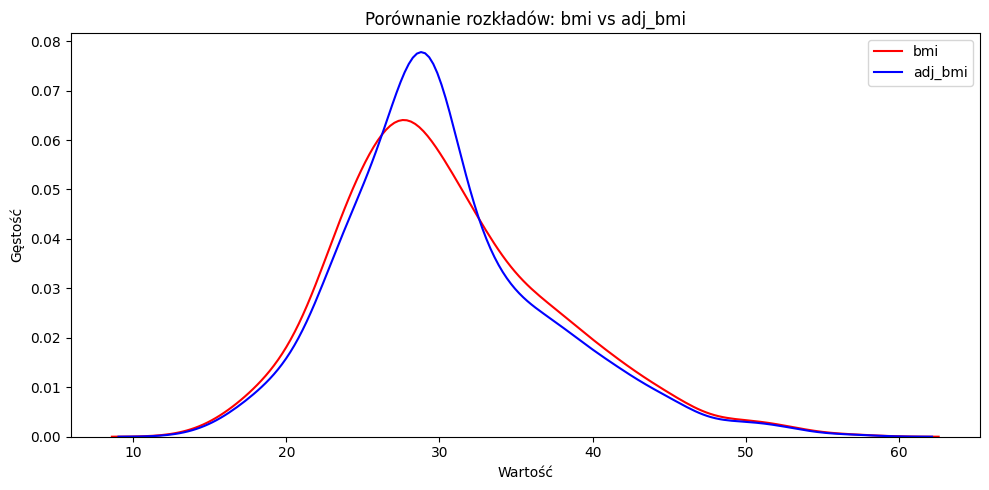

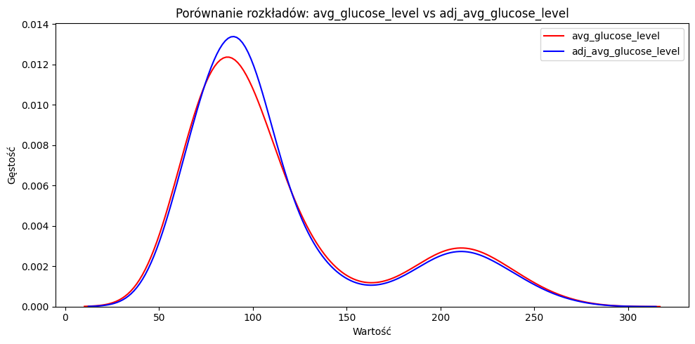

```python
compare_distributions(df, 'bmi', 'adj_bmi', kind='kde')
compare_distributions(df, 'avg_glucose_level', 'adj_avg_glucose_level', kind='kde')
```

```python
def compare_categorical(df, col1, col2, labels=None, figsize=(12, 6)):

    # Ustawienie etykiet
    if labels is None:
        label1, label2 = col1, col2
    else:
        label1, label2 = labels

    # Przygotowanie danych
    counts1 = df[col1].value_counts().sort_index()
    counts2 = df[col2].value_counts().sort_index()

    # Utworzenie wykresu
    fig, (ax1, ax2) = plt.subplots(1, 2, figsize=figsize)

    # Wykres dla col1
    ax1.bar(range(len(counts1)), counts1.values, color='red', alpha=0.7)
    ax1.set_xticks(range(len(counts1)))
    ax1.set_xticklabels(counts1.index, rotation=45, ha='right')
    ax1.set_title(label1)
    ax1.set_ylabel('Liczba wystąpień')
    ax1.grid(axis='y', alpha=0.3)

    # Wykres dla col2
    ax2.bar(range(len(counts2)), counts2.values, color='blue', alpha=0.7)
    ax2.set_xticks(range(len(counts2)))
    ax2.set_xticklabels(counts2.index, rotation=45, ha='right')
    ax2.set_title(label2)
    ax2.set_ylabel('Liczba wystąpień')
    ax2.grid(axis='y', alpha=0.3)

    plt.suptitle(f'Porównanie rozkładów: {label1} vs {label2}', fontsize=14, y=1.02)
    plt.tight_layout()
    plt.show()

    # Wyświetlenie statystyk
    print(f"\n{label1}:")
    print(counts1)
    print(f"\n{label2}:")
    print(counts2)
```

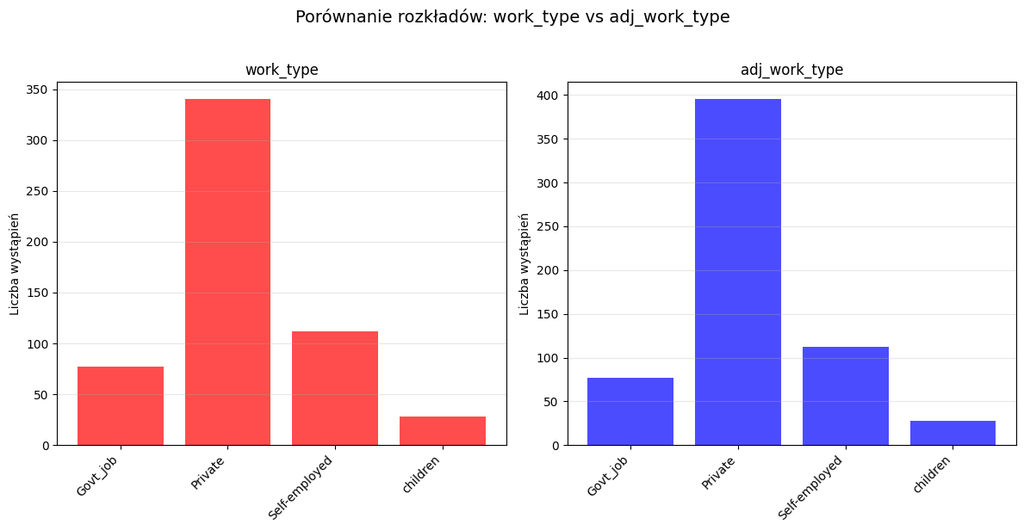

```
work_type:
work_type
Govt_job          77
Private          340
Self-employed    112
children          28
Name: count, dtype: int64

adj_work_type:
adj_work_type
Govt_job          77
Private          395
Self-employed    112
children          28
Name: count, dtype: int64
```

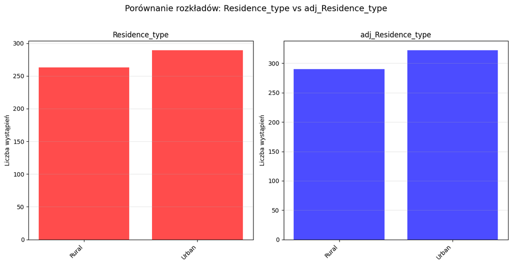

```
Residence_type:
Residence_type
Rural    263
Urban    289
Name: count, dtype: int64

adj_Residence_type:
adj_Residence_type
Rural    290
Urban    322
Name: count, dtype: int64
```

```python
compare_categorical(df, 'work_type', 'adj_work_type')
compare_categorical(df, 'Residence_type','adj_Residence_type')
```

Po analizie wykresów można stwierdzić, że wykorzystanie wartości median oraz mód było dobrym wyborem ze wzgledu na małe zmiany w rozkładach zmiennych. Dodatkowo można stwierdzić, że w przypadku zmiennej *Residedce_type* potrzebne było wykorzystanie rozkładu prawdopodobieństwa danej zmiennej.

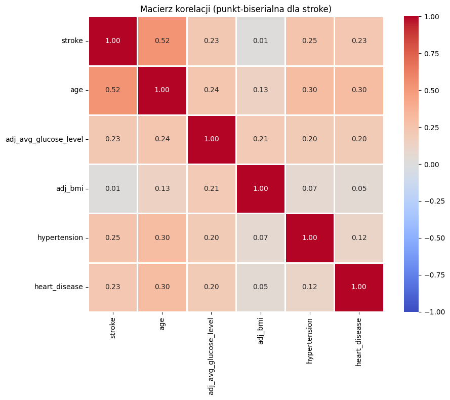

```
Korelacje punkt-biserialne ze zmienną 'stroke':
age                      0.524826
hypertension             0.253555
heart_disease            0.231753
adj_avg_glucose_level    0.225017
adj_bmi                  0.012033
Name: stroke, dtype: float64
```

```python
selected_vars = ['stroke', 'age', 'adj_avg_glucose_level', 'adj_bmi', 'hypertension', 'heart_disease']
df_selected = df[selected_vars]
correlation_matrix = pd.DataFrame(index=selected_vars, columns=selected_vars, dtype=float)

for i, var1 in enumerate(selected_vars):
    for j, var2 in enumerate(selected_vars):
        if var1 == var2:
            correlation_matrix.loc[var1, var2] = 1.0
        elif 'stroke' in [var1, var2]:
            # Korelacja punkt-biserialna gdy jedna zmienna to stroke
            binary_var = var1 if var1 == 'stroke' else var2
            continuous_var = var2 if var1 == 'stroke' else var1

            mask = df[[binary_var, continuous_var]].notna().all(axis=1)
            corr, _ = pointbiserialr(df.loc[mask, binary_var], df.loc[mask, continuous_var])
            correlation_matrix.loc[var1, var2] = corr
        else:
            # Zwykła korelacja Pearsona dla par zmiennych ciągłych
            mask = df[[var1, var2]].notna().all(axis=1)
            corr = df.loc[mask, [var1, var2]].corr().iloc[0, 1]
            correlation_matrix.loc[var1, var2] = corr

# Konwersja na float
correlation_matrix = correlation_matrix.astype(float)

# Wykres
plt.figure(figsize=(10, 8))
sns.heatmap(correlation_matrix, annot=True, cmap='coolwarm', center=0,
            fmt='.2f', square=True, linewidths=1, vmin=-1, vmax=1)
plt.title('Macierz korelacji (punkt-biserialna dla stroke)')
plt.tight_layout()
plt.show()

# Wyświetlenie korelacji ze stroke
print("\nKorelacje punkt-biserialne ze zmienną 'stroke':")
print(correlation_matrix['stroke'].drop('stroke').sort_values(ascending=False))
```

Można stwierdzić o pewnych korelacjach, jednak ze względu na charakter zmiennej objaśnianej (binarna) nie należy przywiązywać do niej większej uwagi. Większą uwagę należy przykuć do tabeli częstości, ale pier dokonano zmiany i zakodowania zmiennej gender jako binarnej.

```python
df['gender'] = df['gender'].map({'Male': 1, 'Female': 0})

categorical_vars = ['gender', 'ever_married', 'adj_work_type', 'adj_Residence_type',
                    'smoking_status', 'stroke']
for var in categorical_vars:
    df[var] = df[var].astype('category')
```

```
============================================================
TABELE CZĘSTOŚCI - ZMIENNE KATEGORYCZNE vs STROKE
============================================================

gender vs stroke:
stroke    0    1  All
gender
0       235  120  355
1       168   89  257
All     403  209  612
------------------------------------------------------------

hypertension vs stroke:
stroke          0    1  All
hypertension
0             366  149  515
1              37   60   97
All           403  209  612
------------------------------------------------------------

heart_disease vs stroke:
stroke           0    1  All
heart_disease
0              384  169  553
1               19   40   59
All            403  209  612
------------------------------------------------------------

ever_married vs stroke:
stroke          0    1  All
ever_married
No            109   23  132
Yes           294  186  480
All           403  209  612
------------------------------------------------------------

adj_work_type vs stroke:
stroke           0    1  All
adj_work_type
Govt_job        51   26   77
```

[output cut: 8 more lines]

```
adj_Residence_type
Rural               193   97  290
Urban               210  112  322
All                 403  209  612
------------------------------------------------------------

smoking_status vs stroke:
stroke             0    1  All
smoking_status
Unknown           94   29  123
formerly smoked   84   57  141
never smoked     154   84  238
smokes            71   39  110
All              403  209  612
------------------------------------------------------------
```

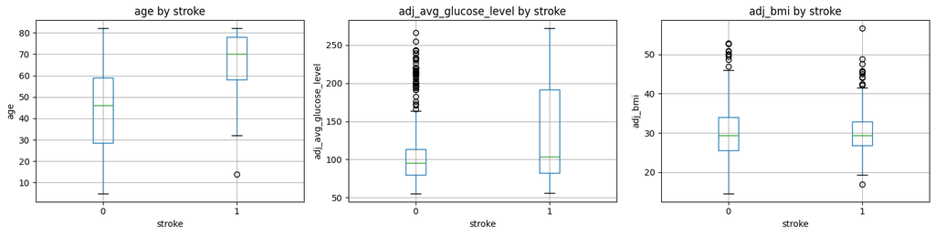

```python
print("=" * 60)
print("TABELE CZĘSTOŚCI - ZMIENNE KATEGORYCZNE vs STROKE")
print("=" * 60)

categorical_features = ['gender', 'hypertension', 'heart_disease', 'ever_married',
                        'adj_work_type', 'adj_Residence_type', 'smoking_status']

for var in categorical_features:
    print(f"\n{var} vs stroke:")
    print(pd.crosstab(df[var], df['stroke'], margins=True))
    print("-" * 60)

# Scatter ploty dla zmiennych numerycznych vs stroke
numeric_vars = ['age', 'adj_avg_glucose_level', 'adj_bmi']

fig, axes = plt.subplots(1, 3, figsize=(15, 4))

for idx, var in enumerate(numeric_vars):
    df.boxplot(column=var, by='stroke', ax=axes[idx])
    axes[idx].set_title(f'{var} by stroke')
    axes[idx].set_xlabel('stroke')
    axes[idx].set_ylabel(var)

plt.suptitle('')
plt.tight_layout()
plt.show()
```

Można zauważyć następujaco:  
płeć nie ma znaczenia dla tych danych - jest w miarę równomierny podział w tabeli częstości,  
osoby posiadające nadciśnienie częściej dostają zawału,  
osoby mające choroby serca częściej dostają zawału,  
dla palenia w tabeli nie widać większych różnic  
wraz z wiekiem rośnie ryzyko zawału,  
również większy poziom glukozy zwiększa ryzyko zawału,  
bmi nie ma bardzo znaczenia dla ryzyka zawału.

```python
print("=" * 60)
print("ROZKŁAD ZMIENNEJ STROKE")
print("=" * 60)

stroke_counts = df['stroke'].value_counts()
stroke_pct = df['stroke'].value_counts(normalize=True) * 100

print("\nLiczebności:")
print(stroke_counts)
print("\nProcenty:")
print(stroke_pct)
print(f"\nStroke = 0: {stroke_pct[0]:.2f}%")
print(f"Stroke = 1: {stroke_pct[1]:.2f}%")
```

```
============================================================
ROZKŁAD ZMIENNEJ STROKE
============================================================

Liczebności:
stroke
0    403
1    209
Name: count, dtype: int64

Procenty:
stroke
0    65.849673
1    34.150327
Name: proportion, dtype: float64

Stroke = 0: 65.85%
Stroke = 1: 34.15%
```

Można zauwazyć w miarę równomierny podział zmiennej objaśnianej.

Poniżej odpowiedzi na pytania do zadania 1.

1. Podział danych na zbiór uczący i testowy to rozdzielenie dostępnych danych na dwie (lub więcej) części:
- Zbiór uczący (train set) – dane, na których model się uczy, tzn. dopasowuje swoje parametry,
- Zbiór testowy (test set) – dane, których model wcześniej nie widział, używane do sprawdzenia, jak dobrze model działa w praktyce (czy potrafi uogólniać).

Dlaczego ten podział jest używany? Aby uniknąć przeuczenia (overfittingu) — sytuacji, gdy model świetnie działa na danych uczących, ale źle na nowych, nieznanych przypadkach.

2. Macierz błędów (pomyłek) to tabela podsumowująca wyniki klasyfikacji (dla problemu binarnego: „pozytywny” vs. „negatywny” przypadek) - na jej podstawie wylicza się 3 metryki.
3. Miary:
- Dokładność (Accuracy) - udział poprawnych klasyfikacji wśród wszystkich przykładów.
- Czułość (Recall / Sensitivity) - mówi, jak dobrze model wykrywa przypadki pozytywne.
- Specyficzność (Specificity) - mówi, jak dobrze model rozpoznaje przypadki negatywne.
- Precision - ile z przewidzianych jako pozytywne faktycznie nimi było.
- F1-score – łączy precyzję i czułość w jedną miarę (harmoniczna średnia).
- AUC / ROC (Area Under the Curve) – pokazuje, jak dobrze model rozdziela klasy niezależnie od progu decyzyjnego.

## Zadanie 2 - knn i przygotowanie danych

```python
feature_cols = ['gender', 'age', 'hypertension', 'heart_disease', 'ever_married',
                'adj_work_type', 'adj_Residence_type', 'adj_avg_glucose_level',
                'adj_bmi', 'smoking_status']

numeric_cols = ['gender', 'age', 'hypertension', 'heart_disease',
                'adj_avg_glucose_level', 'adj_bmi']

# Zmienne kategoryczne do przekodowania
categorical_cols = ['ever_married', 'adj_work_type', 'adj_Residence_type', 'smoking_status']

X_numeric = df[numeric_cols]
X_categorical = pd.get_dummies(df[categorical_cols], drop_first=True)

X = pd.concat([X_numeric, X_categorical], axis=1)
y = df['stroke']

scaler = StandardScaler()
X_scaled = scaler.fit_transform(X)
X_scaled = pd.DataFrame(X_scaled, columns=X.columns)
#standaryzacja dla knn

scaler = StandardScaler()
X_scaled = scaler.fit_transform(X)
X_scaled = pd.DataFrame(X_scaled, columns=X.columns)

#podział - 80-20 testowy i uczący

X_train, X_test, y_train, y_test = train_test_split(X_scaled, y, test_size=0.2,
                                                      random_state=42, stratify=y)

print(f"Zbiór uczący: {X_train.shape[0]} obserwacji")
print(f"Zbiór testowy: {X_test.shape[0]} obserwacji")
print(f"\nRozkład stroke w zbiorze uczącym:")
print(y_train.value_counts(normalize=True) * 100)
print(f"\nRozkład stroke w zbiorze testowym:")
print(y_test.value_counts(normalize=True) * 100)
```

```
Zbiór uczący: 489 obserwacji
Zbiór testowy: 123 obserwacji

Rozkład stroke w zbiorze uczącym:
stroke
0    65.848671
1    34.151329
Name: proportion, dtype: float64

Rozkład stroke w zbiorze testowym:
stroke
0    65.853659
1    34.146341
Name: proportion, dtype: float64
```

```
============================================================
5-KROTNA WALIDACJA KRZYŻOWA DLA RÓŻNYCH k
============================================================
k= 1: accuracy = 0.6361 (+/- 0.0672)
k= 6: accuracy = 0.7076 (+/- 0.0185)
k=11: accuracy = 0.7076 (+/- 0.0270)
k=16: accuracy = 0.7198 (+/- 0.0188)
k=21: accuracy = 0.7280 (+/- 0.0206)
k=26: accuracy = 0.7219 (+/- 0.0371)

>>> Najlepsze k = 23 z accuracy = 0.7301
```

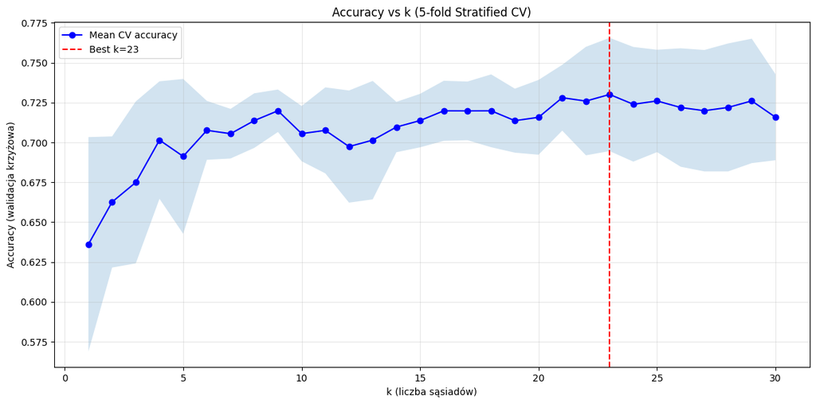

```
============================================================
EWALUACJA MODELU (k=23) NA ZBIORZE TESTOWYM
============================================================

Accuracy: 0.7236

Classification Report:
              precision    recall  f1-score   support

           0       0.74      0.90      0.81        81
           1       0.67      0.38      0.48        42

    accuracy                           0.72       123
   macro avg       0.70      0.64      0.65       123
weighted avg       0.71      0.72      0.70       123


Confusion Matrix:
[[73  8]
 [26 16]]

TP: 16, TN: 73, FP: 8, FN: 26

============================================================
PORÓWNANIE WYBRANYCH WARTOŚCI k NA ZBIORZE TESTOWYM
============================================================
k= 1: test accuracy = 0.6585
k= 3: test accuracy = 0.6260
k= 5: test accuracy = 0.6992
k= 7: test accuracy = 0.7073
k=10: test accuracy = 0.6911
k=15: test accuracy = 0.7154
k=20: test accuracy = 0.7398
k=25: test accuracy = 0.7398
k=30: test accuracy = 0.7398
```

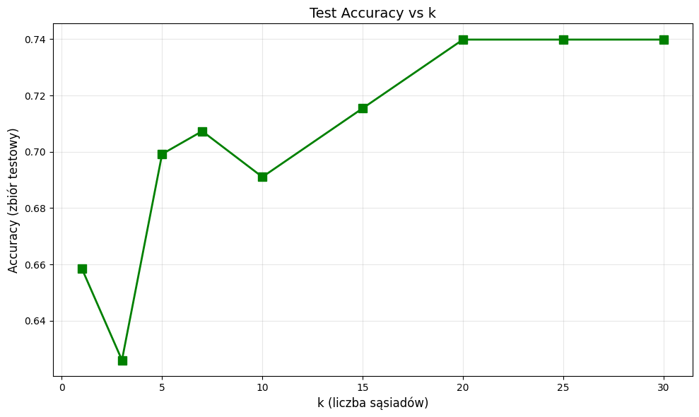

```python
# 1. MODEL KNN - WALIDACJA KRZYŻOWA


print("\n" + "=" * 60)
print("5-KROTNA WALIDACJA KRZYŻOWA DLA RÓŻNYCH k")
print("=" * 60)

k_values = range(1, 31)
cv_scores_mean = []
cv_scores_std = []

skfold = StratifiedKFold(n_splits=5, shuffle=True, random_state=42)

for k in k_values:
    knn = KNeighborsClassifier(n_neighbors=k)
    scores = cross_val_score(knn, X_train, y_train, cv=skfold, scoring='accuracy')
    cv_scores_mean.append(scores.mean())
    cv_scores_std.append(scores.std())

    if k % 5 == 1:
        print(f"k={k:2d}: accuracy = {scores.mean():.4f} (+/- {scores.std():.4f})")

best_k = k_values[np.argmax(cv_scores_mean)]
best_score = max(cv_scores_mean)
print(f"\n>>> Najlepsze k = {best_k} z accuracy = {best_score:.4f}")


# 2. WYKRES: ACCURACY vs k


plt.figure(figsize=(12, 6))
plt.plot(k_values, cv_scores_mean, 'b-', marker='o', label='Mean CV accuracy')
plt.fill_between(k_values,
                 np.array(cv_scores_mean) - np.array(cv_scores_std),
                 np.array(cv_scores_mean) + np.array(cv_scores_std),
                 alpha=0.2)
plt.axvline(x=best_k, color='r', linestyle='--', label=f'Best k={best_k}')
plt.xlabel('k (liczba sąsiadów)')
plt.ylabel('Accuracy (walidacja krzyżowa)')
plt.title('Accuracy vs k (5-fold Stratified CV)')
plt.legend()
plt.grid(True, alpha=0.3)
plt.tight_layout()
plt.show()


# 3. MODEL Z NAJLEPSZYM k - EWALUACJA NA ZBIORZE TESTOWYM


print("\n" + "=" * 60)
print(f"EWALUACJA MODELU (k={best_k}) NA ZBIORZE TESTOWYM")
print("=" * 60)

knn_best = KNeighborsClassifier(n_neighbors=best_k)
knn_best.fit(X_train, y_train)
y_pred = knn_best.predict(X_test)

print(f"\nAccuracy: {accuracy_score(y_test, y_pred):.4f}")
print("\nClassification Report:")
print(classification_report(y_test, y_pred))
print("\nConfusion Matrix:")
cm = confusion_matrix(y_test, y_pred)
print(cm)
print(f"\nTP: {cm[1,1]}, TN: {cm[0,0]}, FP: {cm[0,1]}, FN: {cm[1,0]}")


# 4. PORÓWNANIE RÓŻNYCH k NA ZBIORZE TESTOWYM


print("\n" + "=" * 60)
print("PORÓWNANIE WYBRANYCH WARTOŚCI k NA ZBIORZE TESTOWYM")
print("=" * 60)

test_k_values = [1, 3, 5, 7, 10, 15, 20, 25, 30]
test_accuracies = []

for k in test_k_values:
    knn = KNeighborsClassifier(n_neighbors=k)
    knn.fit(X_train, y_train)
    y_pred = knn.predict(X_test)
    acc = accuracy_score(y_test, y_pred)
    test_accuracies.append(acc)
    print(f"k={k:2d}: test accuracy = {acc:.4f}")

plt.figure(figsize=(10, 6))
plt.plot(test_k_values, test_accuracies, 'g-', marker='s', linewidth=2, markersize=8)
plt.xlabel('k (liczba sąsiadów)', fontsize=12)
plt.ylabel('Accuracy (zbiór testowy)', fontsize=12)
plt.title('Test Accuracy vs k', fontsize=14)
plt.grid(True, alpha=0.3)
plt.tight_layout()
plt.show()
```

```python
cm = confusion_matrix(y_test, y_pred)


print("\nConfusion Matrix:")
print(cm)
print(f"\nTrue Negatives (TN): {cm[0,0]}")
print(f"False Positives (FP): {cm[0,1]}")
print(f"False Negatives (FN): {cm[1,0]}")
print(f"True Positives (TP): {cm[1,1]}")


tn, fp, fn, tp = cm[0,0], cm[0,1], cm[1,0], cm[1,1]
sensitivity = tp / (tp + fn) if (tp + fn) > 0 else 0
specificity = tn / (tn + fp) if (tn + fp) > 0 else 0

print(f"\nSensitivity (Recall dla klasy 1): {sensitivity:.4f}")
print(f"Specificity (Recall dla klasy 0): {specificity:.4f}")
```

```
Confusion Matrix:
[[76  5]
 [27 15]]

True Negatives (TN): 76
False Positives (FP): 5
False Negatives (FN): 27
True Positives (TP): 15

Sensitivity (Recall dla klasy 1): 0.3571
Specificity (Recall dla klasy 0): 0.9383
```

Czułość 0.3571 oznacza, że tylko 35,71% osób z faktycznym zawałem zostało poprawnie wykrytych przez model. Innymi słowy, ok. 64% przypadków zawału model przeoczył (False Negatives). To zły wynik klinicznie, bo w medycynie przeoczenie zawału jest bardzo niebezpieczne.

Odpowiedzi na pytania:

- KNN to metoda klasyfikacji (lub regresji) oparta na podobieństwie między punktami danych. Mamy zbiór uczący – dane, gdzie znamy etykiety klas. Dla nowego punktu (obserwacji bez etykiety):
1. Obliczamy odległość między nim a wszystkimi punktami ze zbioru uczącego (np. euklidesową).
2. Wybieramy k najbliższych sąsiadów (punktów z najmniejszą odległością).
3. Sprawdzamy, jakie klasy występują wśród tych sąsiadów.
4. Nowemu punktowi przypisujemy klasę większościową (w naszym przypadku wartość 0 albo 1) wśród tych sąsiadów.
- k = liczba sąsiadów, których bierzemy pod uwagę przy klasyfikacji. To parametr regulujący złożoność modelu. Dobór wartości k:
1. Małe k (np. 1, 3) - model „nadwrażliwy” na dane, może się przeuczyć (overfitting).
2. Duże k (np. 15, 25) - model uśrednia wyniki, może przeoczyć lokalne zależności (underfitting)
3. Dobrze, jeśli k nie jest parzyste - wtedy łatwiej uniknąć remisu przy głosowaniu.
- Standaryzacja jest bardzo ważna - KNN opiera się na obliczaniu odległości (np. euklidesowej) między punktami. Jeśli cechy mają różne skale, to cecha o większych wartościach zdominuje wynik. (np. 1000 do 1)
- KNN wymaga obliczania odległości między punktami, więc zmienne kategoryczne trzeba najpierw przekształcić np. w One-Hot Encoding (najczęściej stosowany) - 0 i 1.

```
k= 1: accuracy = 0.6361 (+/- 0.0672)
k= 6: accuracy = 0.6872 (+/- 0.0471)
k=11: accuracy = 0.7076 (+/- 0.0243)
k=16: accuracy = 0.7097 (+/- 0.0204)
k=21: accuracy = 0.7157 (+/- 0.0177)
k=26: accuracy = 0.7137 (+/- 0.0279)

>>> Najlepsze k = 18 z accuracy = 0.7260
```

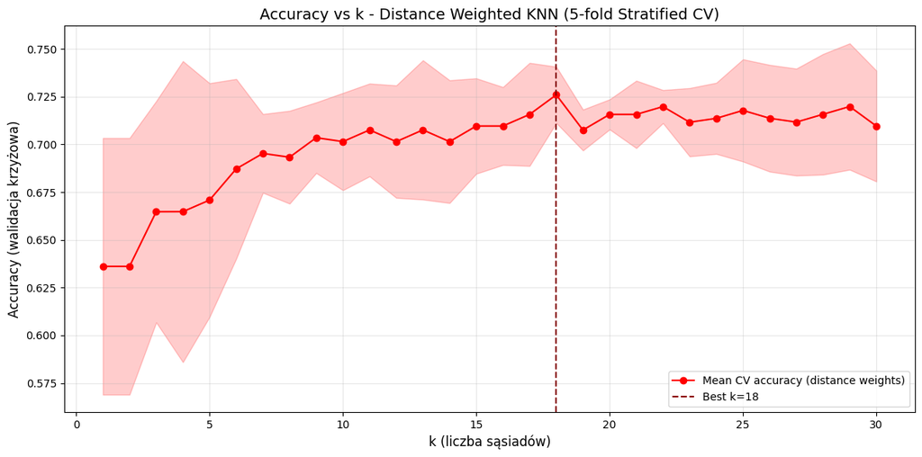

```
================================================================================
EWALUACJA MODELU (k=18, weights='distance') NA ZBIORZE TESTOWYM
================================================================================

Accuracy: 0.6992

Classification Report:
              precision    recall  f1-score   support

           0       0.74      0.84      0.79        81
           1       0.58      0.43      0.49        42

    accuracy                           0.70       123
   macro avg       0.66      0.63      0.64       123
weighted avg       0.69      0.70      0.69       123


Confusion Matrix:
[[68 13]
 [24 18]]

True Negatives (TN): 68
False Positives (FP): 13
False Negatives (FN): 24
True Positives (TP): 18

Sensitivity (Recall dla klasy 1): 0.4286
Specificity (Recall dla klasy 0): 0.8395

================================================================================
PORÓWNANIE WYBRANYCH WARTOŚCI k NA ZBIORZE TESTOWYM (distance weights)
================================================================================
k= 1: test accuracy = 0.6585
k= 3: test accuracy = 0.6341
k= 5: test accuracy = 0.6829
k= 7: test accuracy = 0.6992
k=10: test accuracy = 0.6911
k=15: test accuracy = 0.6911
k=20: test accuracy = 0.7073
k=25: test accuracy = 0.7073
k=30: test accuracy = 0.7154
```

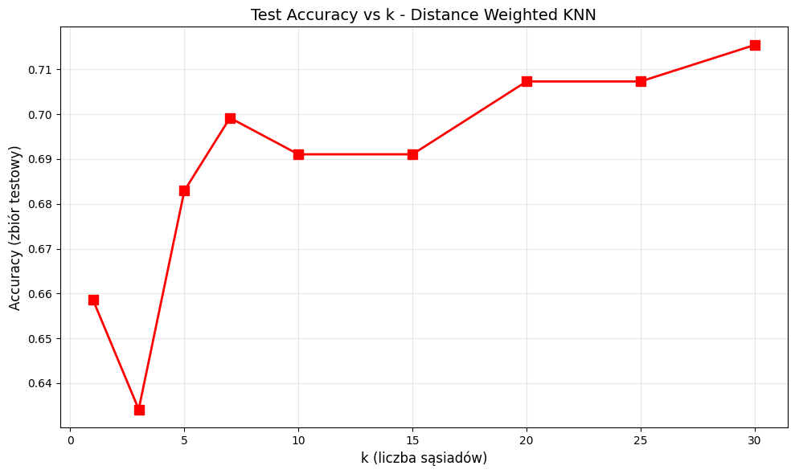

```python
# WAŻONA METODA K-NAJBLIŻSZYCH SĄSIADÓW
#1. WALIDACJA KRZYŻOWA DLA RÓŻNYCH k


k_values_weighted = range(1, 31)
cv_scores_weighted = []
cv_scores_std_weighted = []

skfold = StratifiedKFold(n_splits=5, shuffle=True, random_state=42)

for k in k_values_weighted:
    knn_weighted = KNeighborsClassifier(n_neighbors=k, weights='distance')
    scores = cross_val_score(knn_weighted, X_train, y_train, cv=skfold, scoring='accuracy')
    cv_scores_weighted.append(scores.mean())
    cv_scores_std_weighted.append(scores.std())

    if k % 5 == 1:
        print(f"k={k:2d}: accuracy = {scores.mean():.4f} (+/- {scores.std():.4f})")

# Najlepsze k
best_k_weighted = k_values_weighted[np.argmax(cv_scores_weighted)]
best_score_weighted = max(cv_scores_weighted)
print(f"\n>>> Najlepsze k = {best_k_weighted} z accuracy = {best_score_weighted:.4f}")


# 2. WYKRES: ACCURACY vs k

plt.figure(figsize=(12, 6))
plt.plot(k_values_weighted, cv_scores_weighted, 'r-', marker='o', label='Mean CV accuracy (distance weights)')
plt.fill_between(k_values_weighted,
                 np.array(cv_scores_weighted) - np.array(cv_scores_std_weighted),
                 np.array(cv_scores_weighted) + np.array(cv_scores_std_weighted),
                 alpha=0.2, color='red')
plt.axvline(x=best_k_weighted, color='darkred', linestyle='--', label=f'Best k={best_k_weighted}')
plt.xlabel('k (liczba sąsiadów)', fontsize=12)
plt.ylabel('Accuracy (walidacja krzyżowa)', fontsize=12)
plt.title('Accuracy vs k - Distance Weighted KNN (5-fold Stratified CV)', fontsize=14)
plt.legend()
plt.grid(True, alpha=0.3)
plt.tight_layout()
plt.show()

# 3. MODEL Z NAJLEPSZYM k - EWALUACJA NA ZBIORZE TESTOWYM


print("\n" + "=" * 80)
print(f"EWALUACJA MODELU (k={best_k_weighted}, weights='distance') NA ZBIORZE TESTOWYM")
print("=" * 80)

knn_weighted_best = KNeighborsClassifier(n_neighbors=best_k_weighted, weights='distance')
knn_weighted_best.fit(X_train, y_train)
y_pred_weighted = knn_weighted_best.predict(X_test)

print(f"\nAccuracy: {accuracy_score(y_test, y_pred_weighted):.4f}")
print("\nClassification Report:")
print(classification_report(y_test, y_pred_weighted))


# 4. CONFUSION MATRIX


cm_weighted = confusion_matrix(y_test, y_pred_weighted)

print("\nConfusion Matrix:")
print(cm_weighted)
print(f"\nTrue Negatives (TN): {cm_weighted[0,0]}")
print(f"False Positives (FP): {cm_weighted[0,1]}")
print(f"False Negatives (FN): {cm_weighted[1,0]}")
print(f"True Positives (TP): {cm_weighted[1,1]}")

# Dodatkowe metryki
tn, fp, fn, tp = cm_weighted[0,0], cm_weighted[0,1], cm_weighted[1,0], cm_weighted[1,1]
sensitivity = tp / (tp + fn) if (tp + fn) > 0 else 0
specificity = tn / (tn + fp) if (tn + fp) > 0 else 0

print(f"\nSensitivity (Recall dla klasy 1): {sensitivity:.4f}")
print(f"Specificity (Recall dla klasy 0): {specificity:.4f}")


# 5. PORÓWNANIE RÓŻNYCH k NA ZBIORZE TESTOWYM


print("\n" + "=" * 80)
print("PORÓWNANIE WYBRANYCH WARTOŚCI k NA ZBIORZE TESTOWYM (distance weights)")
print("=" * 80)

test_k_values = [1, 3, 5, 7, 10, 15, 20, 25, 30]
test_accuracies_weighted = []

for k in test_k_values:
    knn = KNeighborsClassifier(n_neighbors=k, weights='distance')
    knn.fit(X_train, y_train)
    y_pred = knn.predict(X_test)
    acc = accuracy_score(y_test, y_pred)
    test_accuracies_weighted.append(acc)
    print(f"k={k:2d}: test accuracy = {acc:.4f}")

plt.figure(figsize=(10, 6))
plt.plot(test_k_values, test_accuracies_weighted, 'r-', marker='s', linewidth=2, markersize=8)
plt.xlabel('k (liczba sąsiadów)', fontsize=12)
plt.ylabel('Accuracy (zbiór testowy)', fontsize=12)
plt.title('Test Accuracy vs k - Distance Weighted KNN', fontsize=14)
plt.grid(True, alpha=0.3)
plt.tight_layout()
plt.show()
```

Tu można zauwazyć, że dla tej metody czułość się zwiększyła, co świadczy o lepszym dopasowaniu dla tych danych (wykrycie zawału, pomimo delikatnie mniejszej dokładności).

Odpowiedzi na pytania:

- w ważonej KNN sąsiedzi nie są równi. Każdemu sąsiadowi przypisuje się wagę zależną od odległości – im bliżej nowego punktu, tym większy wpływ na wynik.
- w klasycznym KNN wybór k jest bardzo krytyczny – małe k = przeuczenie, duże k = zbyt duże uogólnienie. W ważonej KNN wpływ dalszych sąsiadów sprawia, że wynik jest mniej wrażliwy na dokładną wartość k, co sprawia, że można używać większego k bez dużej utraty jakości.

```python
## Logit
```

Odpowiedzi na pytania:

1. Podstawowe założenia regresji logistycznej to:
- zmienna zależna powinna być dychotomiczna, czyli przyjmować tylko dwie wartości, na przykład 0 i 1,
- regresja logistyczna nie zakłada liniowej zależności między zmiennymi niezależnymi a samą zmienną wynikową, ale zakłada, że istnieje liniowa zależność pomiędzy zmiennymi niezależnymi a logarytmem ilorazu szans (czyli logitem),
- ważne jest również, aby obserwacje były od siebie niezależne, a pomiędzy predyktorami nie występowała silna wielokolinearność, ponieważ utrudnia to interpretację współczynników,
- model ten jest też wrażliwy na obecność wartości odstających, które mogą zaburzyć wyniki.
2. W przypadku zmiennych kategorycznych regresja logistyczna radzi sobie z nimi dobrze, o ile zostaną odpowiednio zakodowane. Najczęściej stosuje się kodowanie typu one-hot lub tzw. kodowanie zmiennych fikcyjnych (dummy coding), w którym jedna z kategorii pełni rolę kategorii referencyjnej.
3. Standaryzacja danych nie jest matematycznie wymagana w regresji logistycznej.
4. Wartości odstające mają w regresji logistycznej istotny wpływ na wyniki, ponieważ metoda ta opiera się na maksymalizacji funkcji wiarygodności. Obserwacje, które znacząco odbiegają od reszty, mogą przesunąć estymowane współczynniki i tym samym zniekształcić interpretację modelu.
5. Wyniki regresji logistycznej interpretuje się poprzez współczynniki β, które opisują wpływ zmiennych niezależnych na tzw. log-odds, czyli logarytm ilorazu szans wystąpienia zdarzenia. Dla każdej zmiennej niezależnej β pokazuje, jak bardzo zmienia się log-iloraz szans, gdy dana zmienna wzrasta o jednostkę, przy założeniu, że inne zmienne pozostają stałe. Częściej jednak stosuje się interpretację poprzez przekształcenie wykładnicze e^β, które daje tzw. iloraz szans (odds ratio). Wartość e^β większa od 1 oznacza, że wzrost zmiennej zwiększa prawdopodobieństwo zajścia zdarzenia, natomiast wartość mniejsza od 1 oznacza jego spadek.

```
================================================================================
EWALUACJA MODELU NA ZBIORZE TESTOWYM (threshold = 0.6)
================================================================================

Accuracy: 0.7480
ROC AUC Score: 0.8110

Classification Report:
              precision    recall  f1-score   support

           0       0.78      0.85      0.82        81
           1       0.66      0.55      0.60        42

    accuracy                           0.75       123
   macro avg       0.72      0.70      0.71       123
weighted avg       0.74      0.75      0.74       123


Confusion Matrix:
[[69 12]
 [19 23]]

True Negatives (TN): 69
False Positives (FP): 12
False Negatives (FN): 19
True Positives (TP): 23

Sensitivity (Recall dla klasy 1): 0.5476
Specificity (Recall dla klasy 0): 0.8519
```

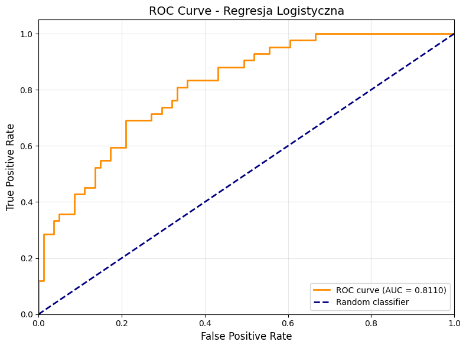

```
================================================================================
WSPÓŁCZYNNIKI MODELU (feature importance)
================================================================================

Top 10 najważniejszych zmiennych:
                       Feature  Coefficient  Abs_Coefficient
                           age     1.609906         1.609906
                  hypertension     0.251867         0.251867
        adj_work_type_children     0.227578         0.227578
         adj_avg_glucose_level     0.206287         0.206287
                       adj_bmi    -0.152423         0.152423
   smoking_status_never smoked    -0.134790         0.134790
              ever_married_Yes    -0.117538         0.117538
   adj_work_type_Self-employed    -0.114655         0.114655
smoking_status_formerly smoked     0.092199         0.092199
         adj_work_type_Private     0.090888         0.090888
```

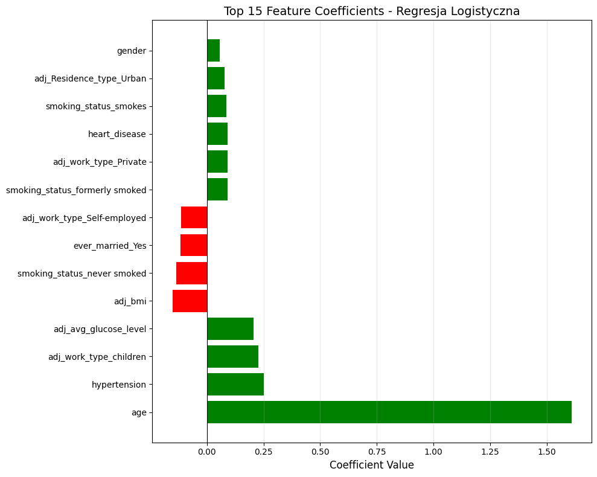

```
================================================================================
5-KROTNA WALIDACJA KRZYŻOWA
================================================================================

CV Accuracy scores: [0.69387755 0.78571429 0.81632653 0.73469388 0.77319588]
Mean CV Accuracy: 0.7608 (+/- 0.0425)
Mean CV ROC AUC: 0.8280 (+/- 0.0264)
```

```python
# 1. MODEL REGRESJI LOGISTYCZNEJ
log_reg = LogisticRegression(max_iter=1000, random_state=42)
log_reg.fit(X_train, y_train)
y_pred_proba_log = log_reg.predict_proba(X_test)[:, 1]  # prawdopodobieństwa dla klasy 1

threshold = 0.6
y_pred_log = (y_pred_proba_log >= threshold).astype(int)

print("\n" + "=" * 80)
print(f"EWALUACJA MODELU NA ZBIORZE TESTOWYM (threshold = {threshold})")
print("=" * 80)


# 2. METRYKI PODSTAWOWE
print(f"\nAccuracy: {accuracy_score(y_test, y_pred_log):.4f}")
print(f"ROC AUC Score: {roc_auc_score(y_test, y_pred_proba_log):.4f}")

print("\nClassification Report:")
print(classification_report(y_test, y_pred_log))

# 3. CONFUSION MATRIX

cm_log = confusion_matrix(y_test, y_pred_log)

print("\nConfusion Matrix:")
print(cm_log)
print(f"\nTrue Negatives (TN): {cm_log[0,0]}")
print(f"False Positives (FP): {cm_log[0,1]}")
print(f"False Negatives (FN): {cm_log[1,0]}")
print(f"True Positives (TP): {cm_log[1,1]}")

# Dodatkowe metryki
tn, fp, fn, tp = cm_log[0,0], cm_log[0,1], cm_log[1,0], cm_log[1,1]
sensitivity = tp / (tp + fn) if (tp + fn) > 0 else 0
specificity = tn / (tn + fp) if (tn + fp) > 0 else 0

print(f"\nSensitivity (Recall dla klasy 1): {sensitivity:.4f}")
print(f"Specificity (Recall dla klasy 0): {specificity:.4f}")


# 4. KRZYWA ROC


fpr, tpr, thresholds = roc_curve(y_test, y_pred_proba_log)
roc_auc = roc_auc_score(y_test, y_pred_proba_log)

plt.figure(figsize=(8, 6))
plt.plot(fpr, tpr, color='darkorange', lw=2, label=f'ROC curve (AUC = {roc_auc:.4f})')
plt.plot([0, 1], [0, 1], color='navy', lw=2, linestyle='--', label='Random classifier')
plt.xlim([0.0, 1.0])
plt.ylim([0.0, 1.05])
plt.xlabel('False Positive Rate', fontsize=12)
plt.ylabel('True Positive Rate', fontsize=12)
plt.title('ROC Curve - Regresja Logistyczna', fontsize=14)
plt.legend(loc="lower right")
plt.grid(True, alpha=0.3)
plt.tight_layout()
plt.show()


# 5. WSPÓŁCZYNNIKI MODELU

print("\n" + "=" * 80)
print("WSPÓŁCZYNNIKI MODELU (feature importance)")
print("=" * 80)

# współczynniki
coefficients = pd.DataFrame({
    'Feature': X.columns,
    'Coefficient': log_reg.coef_[0]
})
coefficients['Abs_Coefficient'] = np.abs(coefficients['Coefficient'])
coefficients = coefficients.sort_values('Abs_Coefficient', ascending=False)

print("\nTop 10 najważniejszych zmiennych:")
print(coefficients.head(10).to_string(index=False))

# Wizualizacja współczynników
plt.figure(figsize=(10, 8))
top_features = coefficients.head(15)
colors = ['green' if x > 0 else 'red' for x in top_features['Coefficient']]
plt.barh(range(len(top_features)), top_features['Coefficient'], color=colors)
plt.yticks(range(len(top_features)), top_features['Feature'])
plt.xlabel('Coefficient Value', fontsize=12)
plt.title('Top 15 Feature Coefficients - Regresja Logistyczna', fontsize=14)
plt.axvline(x=0, color='black', linestyle='-', linewidth=0.8)
plt.grid(True, alpha=0.3, axis='x')
plt.tight_layout()
plt.show()


# 6. WALIDACJA KRZYŻOWA


print("\n" + "=" * 80)
print("5-KROTNA WALIDACJA KRZYŻOWA")
print("=" * 80)

from sklearn.model_selection import StratifiedKFold, cross_val_score

skfold = StratifiedKFold(n_splits=5, shuffle=True, random_state=42)
cv_scores_log = cross_val_score(log_reg, X_train, y_train, cv=skfold, scoring='accuracy')

print(f"\nCV Accuracy scores: {cv_scores_log}")
print(f"Mean CV Accuracy: {cv_scores_log.mean():.4f} (+/- {cv_scores_log.std():.4f})")

# Dodatkowe metryki z CV
cv_scores_roc = cross_val_score(log_reg, X_train, y_train, cv=skfold, scoring='roc_auc')
print(f"Mean CV ROC AUC: {cv_scores_roc.mean():.4f} (+/- {cv_scores_roc.std():.4f})")
```